# respostas_ex03_21202510146_dias

Debora Rodrigues Pereira Dias

2026-01-31

## R Markdown

Exercício 1 — Aquecimento: Tabela vs. Gráfico

```r
# Base interna do R
data(cars)

# Exibir as 10 primeiras linhas
head(cars, 10)
```

```
##    speed dist
## 1      4    2
## 2      4   10
## 3      7    4
## 4      7   22
## 5      8   16
## 6      9   10
## 7     10   18
## 8     10   26
## 9     10   34
## 10    11   17
```

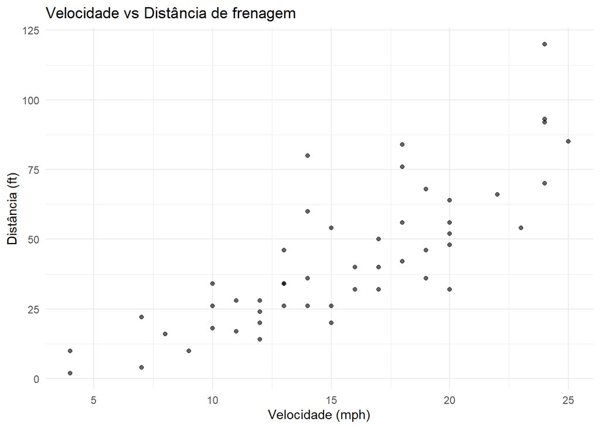

```r
# Gráfico de dispersão speed × dist
ggplot(cars, aes(x = speed, y = dist)) +
  geom_point(alpha = 0.6) +
  labs(title = "Velocidade vs Distância de frenagem",
       x = "Velocidade (mph)", y = "Distância (ft)") +
  theme_minimal()
```

Interpretação:  
A tabela mostra valores individuais, mas o gráfico de dispersão revela a tendência positiva: quanto maior a velocidade, maior tende a ser a distância de frenagem.

Exercício 2 — Distribuições univariadas e grupos

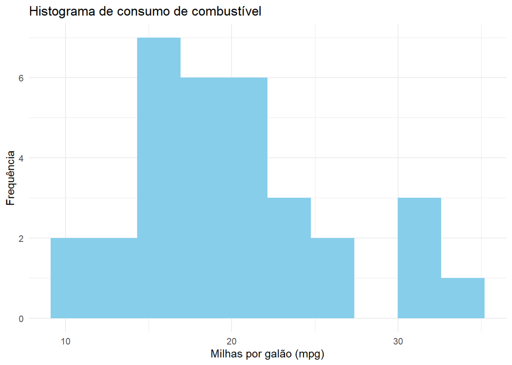

```r
# Base interna mtcars
data(mtcars)
mtcars <- mtcars |> mutate(cyl = as.factor(cyl)) # converter em fator

# Histograma de mpg
ggplot(mtcars, aes(x = mpg)) +
  geom_histogram(bins = 10, fill="skyblue") +
  labs(title = "Histograma de consumo de combustível",
       x = "Milhas por galão (mpg)", y = "Frequência") +
  theme_minimal()
```

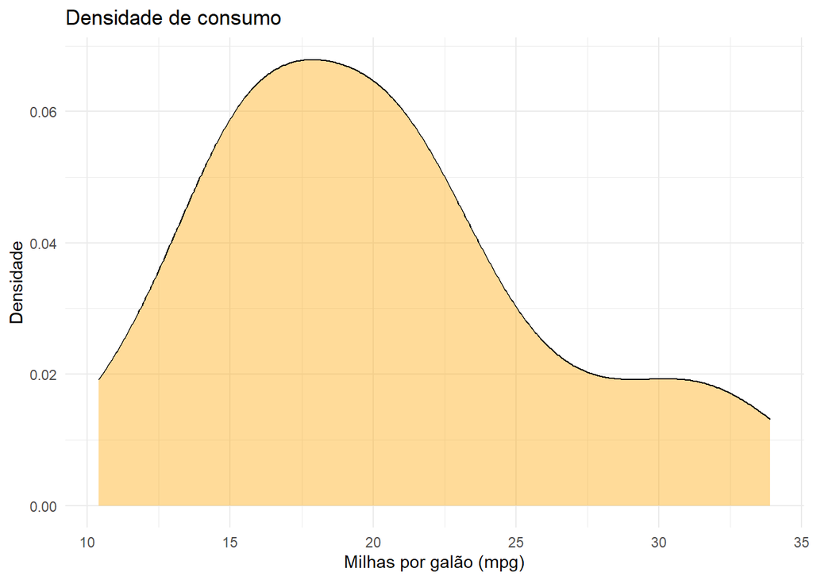

```r
# Densidade de mpg
ggplot(mtcars, aes(x = mpg)) +
  geom_density(alpha = 0.4, fill="orange") +
  labs(title = "Densidade de consumo",
       x = "Milhas por galão (mpg)", y = "Densidade") +
  theme_minimal()
```

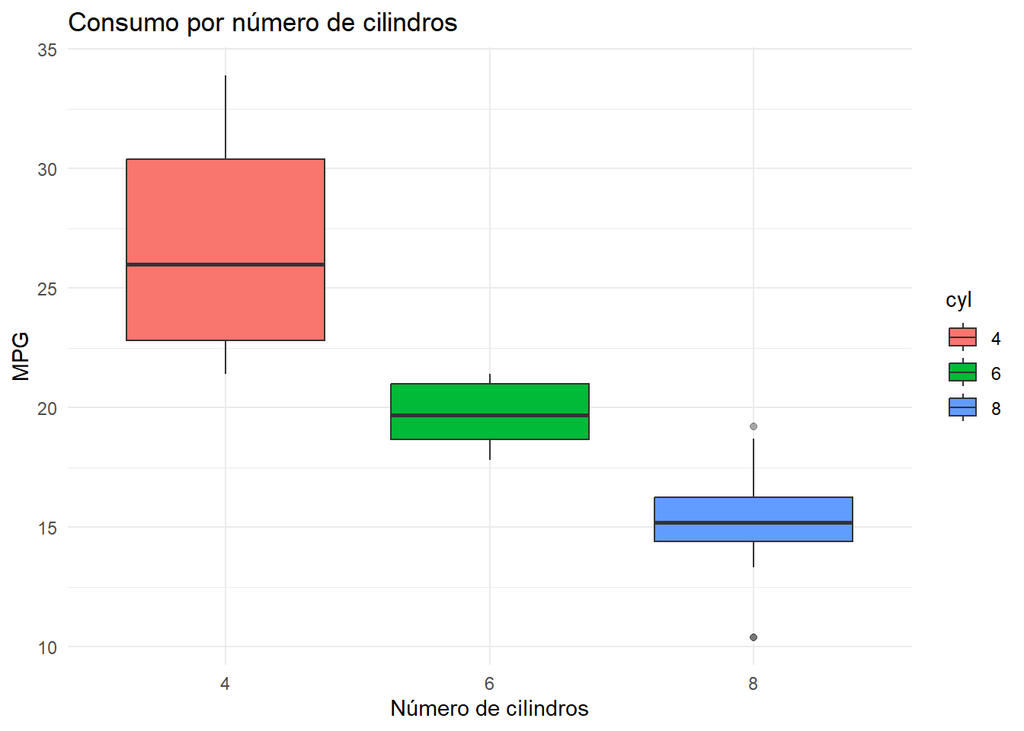

```r
# Boxplot de mpg por número de cilindros
ggplot(mtcars, aes(x = cyl, y = mpg, fill=cyl)) +
  geom_boxplot(show.legend = TRUE, outlier.alpha = 0.4) +
  labs(title = "Consumo por número de cilindros",
       x = "Número de cilindros", y = "MPG") +
  theme_minimal()
```

Interpretação:  
O consumo se concentra entre 15 e 25 mpg. Carros com mais cilindros consomem mais combustível, enquanto os de 4 cilindros são mais eficientes.

Exercício 3 — Série temporal (airquality)

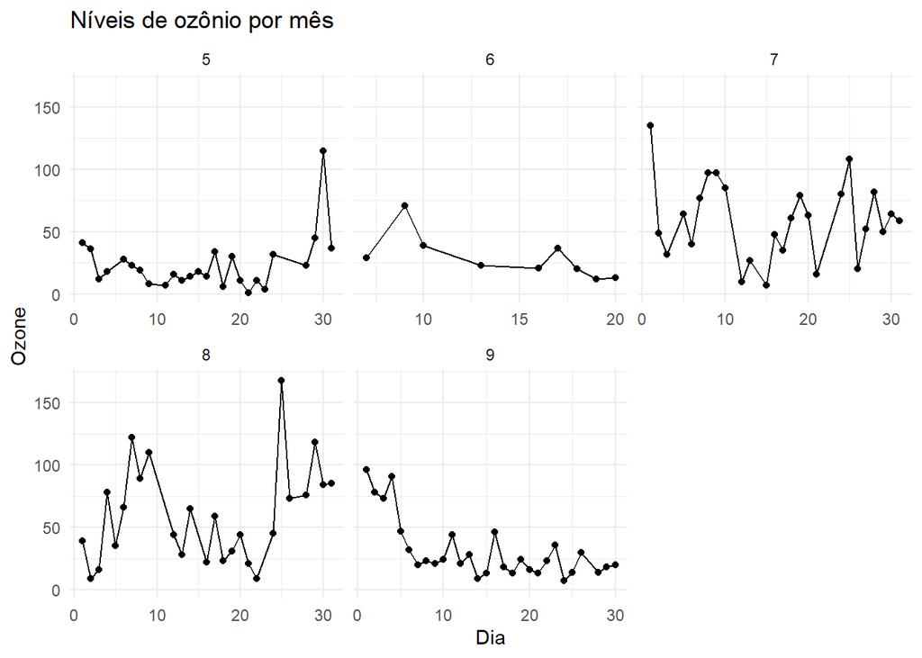

```r
# Base interna airquality
data("airquality")

# Preparar dados
aq <- airquality |>
  as_tibble() |>
  drop_na(Ozone) |>
  mutate(Month = factor(Month),
         Day = as.integer(Day))

# Gráfico de série temporal facetado por mês
ggplot(aq, aes(x = Day, y = Ozone)) +
  geom_line() +
  geom_point() +
  facet_wrap(~ Month, scale = "free_x") +
  labs(title = "Níveis de ozônio por mês",
       x = "Dia", y = "Ozone") +
  theme_minimal()
```

Interpretação:  
O gráfico mostra a variação diária dos níveis de ozônio ao longo dos meses. Observa-se tendência de aumento em alguns meses (como julho e agosto), enquanto em outros os valores permanecem mais baixos ou oscilam bastante. Isso sugere padrões sazonais na concentração de ozônio.

Exercício 4 — Relações bivariadas e transformações

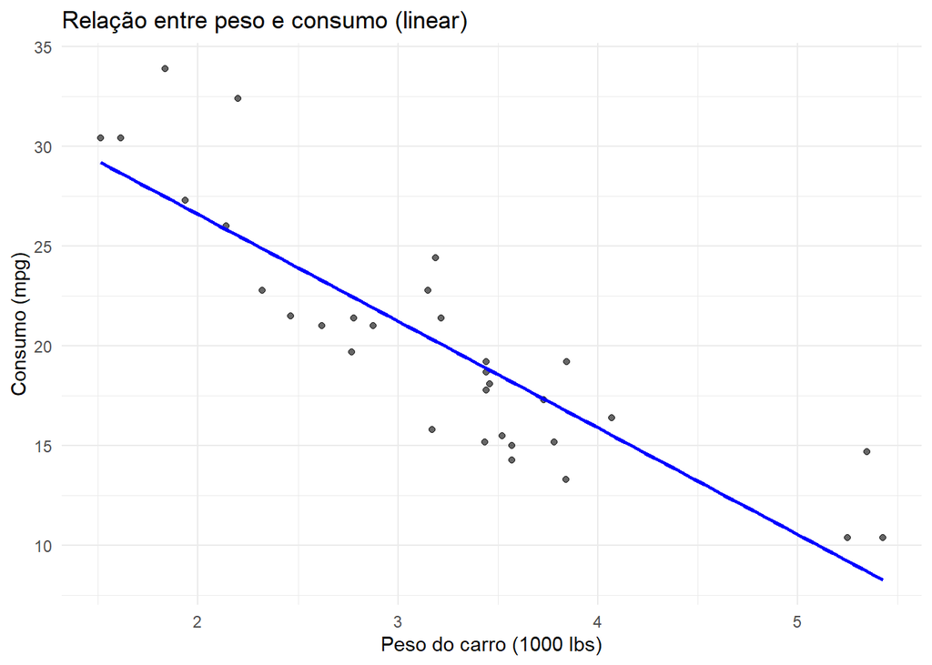

```r
# Gráfico de dispersão com regressão linear
ggplot(mtcars, aes(x = wt, y = mpg)) +
  geom_point(alpha = 0.6) +
  geom_smooth(method = "lm", color = "blue", se = FALSE) +
  labs(title = "Relação entre peso e consumo (linear)",
       x = "Peso do carro (1000 lbs)", y = "Consumo (mpg)") +
  theme_minimal()
```

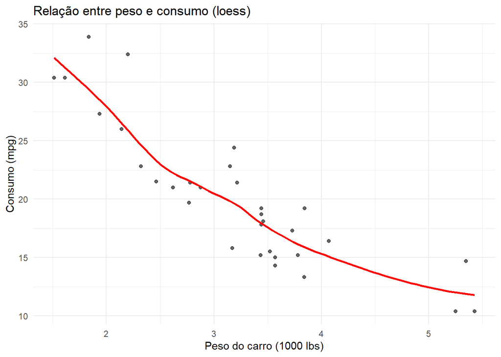

```r
# Gráfico com suavização loess
ggplot(mtcars, aes(x = wt, y = mpg)) +
  geom_point(alpha = 0.6) +
  geom_smooth(method = "loess", color = "red", se = FALSE) +
  labs(title = "Relação entre peso e consumo (loess)",
       x = "Peso do carro (1000 lbs)", y = "Consumo (mpg)") +
  theme_minimal()
```

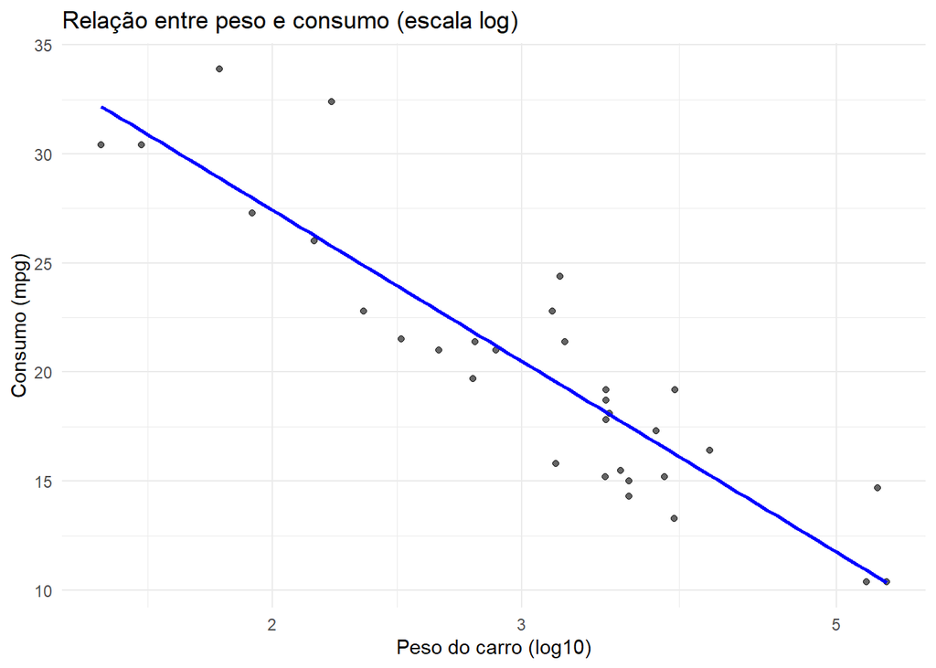

```r
# Gráfico com escala log no eixo x
ggplot(mtcars, aes(x = wt, y = mpg)) +
  geom_point(alpha = 0.6) +
  geom_smooth(method = "lm", color = "blue", se = FALSE) +
  scale_x_log10() +
  labs(title = "Relação entre peso e consumo (escala log)",
       x = "Peso do carro (log10)", y = "Consumo (mpg)") +
  theme_minimal()
```

Interpretação:  
Os gráficos mostram uma relação negativa entre peso e consumo: carros mais pesados tendem a consumir mais combustível. A regressão linear confirma a tendência decrescente, enquanto o loess mostra pequenas variações locais. A escala log no eixo de peso ajuda a visualizar melhor os carros mais leves, mas não altera a tendência geral.

Exercício 5 — Facetas (comparar subgrupos por transmissão)

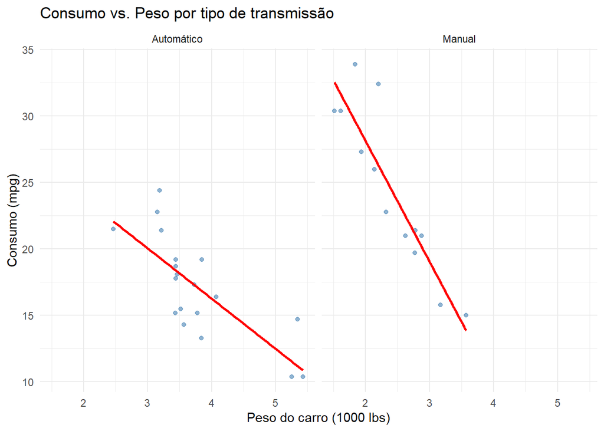

```r
# Preparar fator para transmissão
mtcars <- mtcars |>
  mutate(am = factor(am, labels = c("Automático", "Manual")))

# Gráfico de dispersão mpg x wt, facetado por tipo de transmissão
ggplot(mtcars, aes(x = wt, y = mpg)) +
  geom_point(alpha = 0.6, color = "steelblue") +
  geom_smooth(method = "lm", se = FALSE, color = "red") +
  facet_wrap(~ am) +
  labs(title = "Consumo vs. Peso por tipo de transmissão",
       x = "Peso do carro (1000 lbs)", y = "Consumo (mpg)") +
  theme_minimal()
```

Interpretação:  
O gráfico facetado mostra que, em ambos os tipos de transmissão, há relação negativa entre peso e consumo (carros mais pesados consomem mais). No entanto, os carros manuais tendem a apresentar consumo ligeiramente maior em comparação aos automáticos, para pesos semelhantes.

Exercício 6 — Simulação I: Correlação controlada

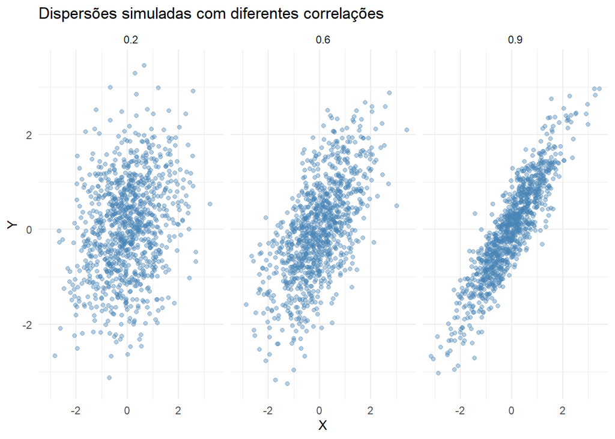

```r
# Simulação de correlação controlada
set.seed(123) # para reprodutibilidade
n <- 1000
rhos <- c(0.2, 0.6, 0.9)

# Gerar dados simulados para diferentes correlações
sim <- purrr::map_dfr(rhos, \(rho) {
  x <- rnorm(n)
  e <- rnorm(n)
  y <- rho * x + sqrt(1 - rho^2) * e
  tibble(rho = rho, x = x, y = y)
})

# Gráfico de dispersão facetado por nível de correlação
ggplot(sim, aes(x = x, y = y)) +
  geom_point(alpha = 0.4, color = "steelblue") +
  facet_wrap(~ rho) +
  labs(title = "Dispersões simuladas com diferentes correlações",
       x = "X", y = "Y") +
  theme_minimal()
```

Interpretação:

Quando ρ = 0.2, a nuvem de pontos é bem espalhada, mostrando correlação fraca.

Com ρ = 0.6, os pontos ficam mais alinhados, indicando correlação moderada.

Com ρ = 0.9, a nuvem fica muito apertada em torno de uma linha, mostrando correlação forte.

Assim, quanto maior o valor de ρ, mais clara e estreita é a relação linear entre X e Y.

Exercício 7 — Simulação II: Diferenças entre grupos

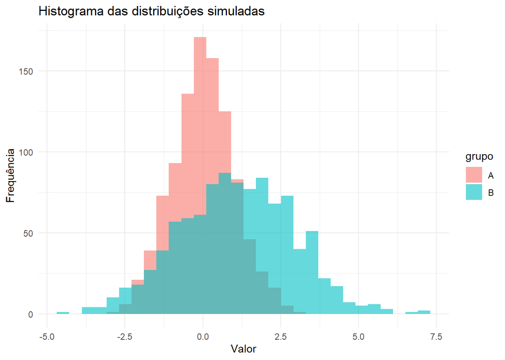

```r
# Simulação de dois grupos
set.seed(123) # para reprodutibilidade
n <- 1000
df_grupos <- tibble(
  grupo = rep(c("A","B"), each = n),
  valor = c(rnorm(n, 0, 1), rnorm(n, 1, 1.8))
)

# Histograma
ggplot(df_grupos, aes(x = valor, fill = grupo)) +
  geom_histogram(alpha = 0.6, position = "identity", bins = 30) +
  labs(title = "Histograma das distribuições simuladas",
       x = "Valor", y = "Frequência") +
  theme_minimal()
```

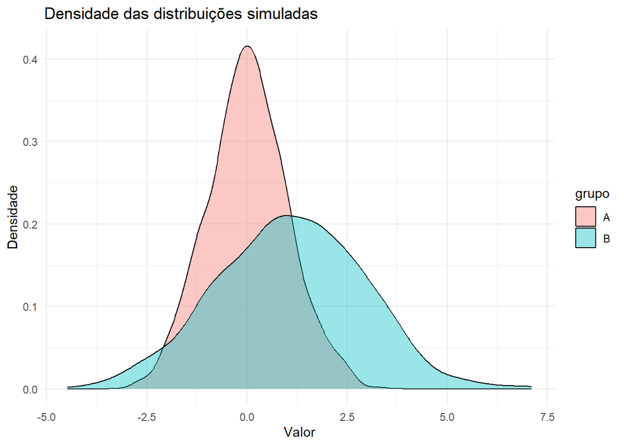

```r
# Densidade
ggplot(df_grupos, aes(x = valor, fill = grupo)) +
  geom_density(alpha = 0.4) +
  labs(title = "Densidade das distribuições simuladas",
       x = "Valor", y = "Densidade") +
  theme_minimal()
```

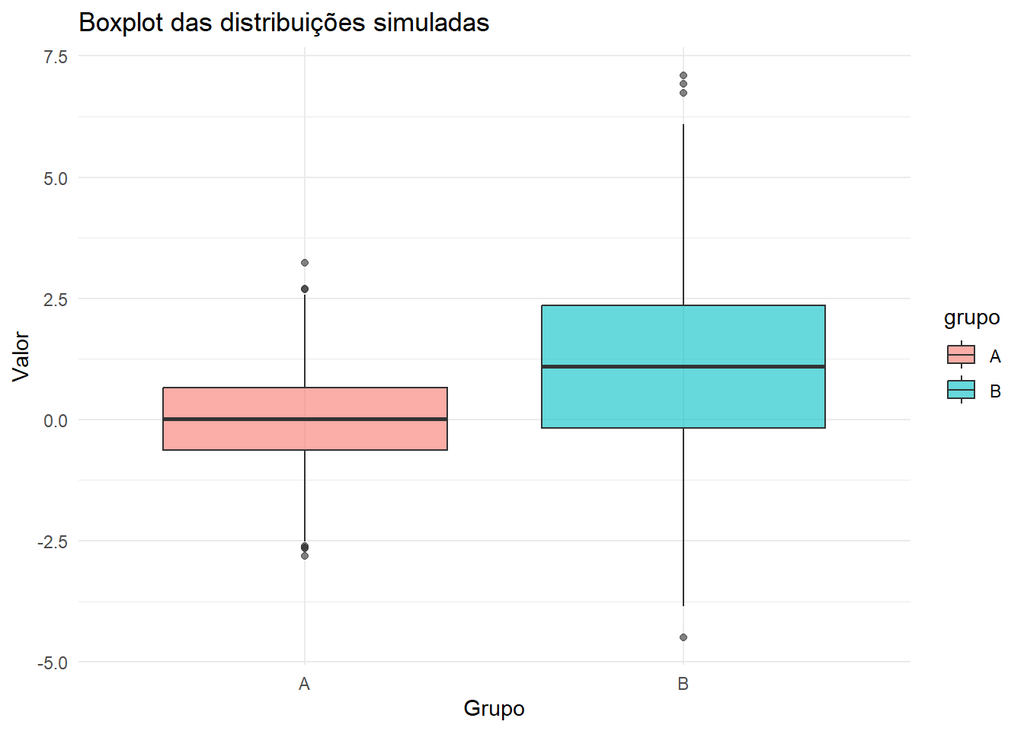

```r
# Boxplot
ggplot(df_grupos, aes(x = grupo, y = valor, fill = grupo)) +
  geom_boxplot(alpha = 0.6) +
  labs(title = "Boxplot das distribuições simuladas",
       x = "Grupo", y = "Valor") +
  theme_minimal()
```

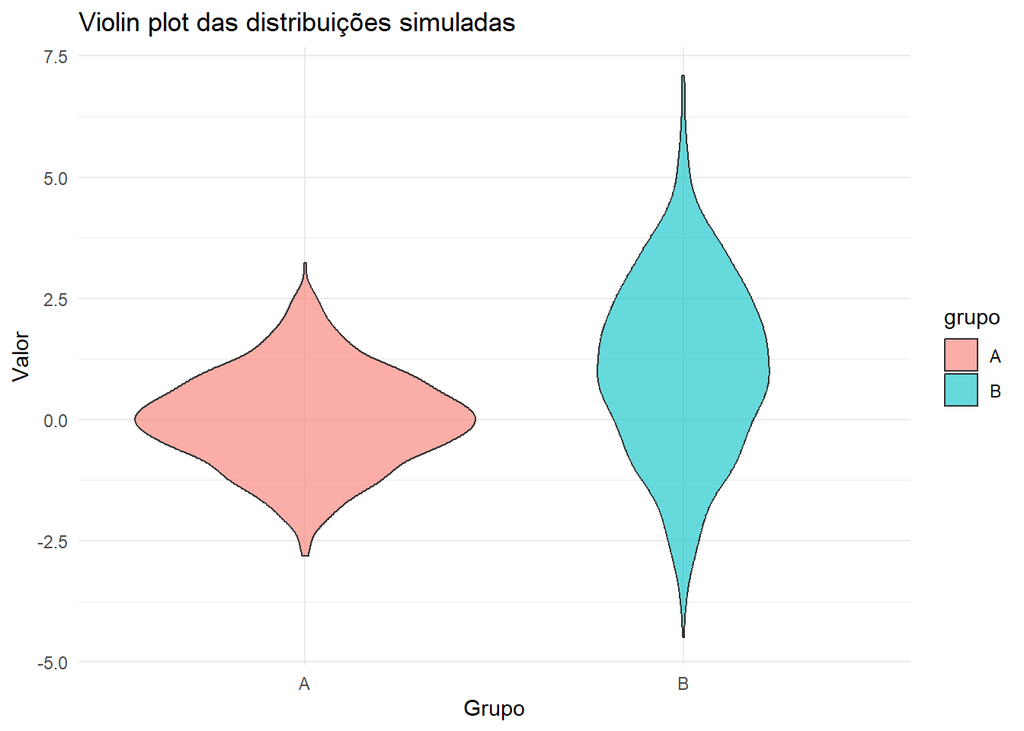

```r
# Violin plot
ggplot(df_grupos, aes(x = grupo, y = valor, fill = grupo)) +
  geom_violin(alpha = 0.6) +
  labs(title = "Violin plot das distribuições simuladas",
       x = "Grupo", y = "Valor") +
  theme_minimal()
```

Interpretação:

O grupo A apresenta distribuição centrada em 0, com menor dispersão.

O grupo B tem média deslocada para 1 e maior variabilidade (dispersão mais ampla).

Os gráficos mostram que o grupo B é mais heterogêneo, enquanto o grupo A é mais concentrado.

Assim, diferenças de média e desvio padrão afetam tanto a posição quanto a forma das distribuições.

Exercício 8 — Exploração da base educ_saude.csv

```r
# Carregar a base educ_saude.csv
library(readr)
educ <- read_csv("data/educ_saude.csv")
# Visualizar estrutura
glimpse(educ)
```

```
## Rows: 10,000
## Columns: 13
## $ id                <chr> "P00001", "P00002", "P00003", "P00004", "P00005", "P…
## $ sexo              <chr> "M", "F", "F", "F", "F", "F", "F", "F", "F", "F", "M…
## $ escolaridade      <chr> "Médio", "Médio", "Médio", "Médio", "Médio", "Médio"…
## $ anos_estudo       <dbl> 10, 9, 9, 10, 11, 11, 10, 8, 15, 11, 6, 7, 5, 4, 10,…
## $ rede_escolar      <chr> "privada", "pública", "pública", "pública", "pública…
## $ municipio         <chr> "Santos", "Dourados", "Várzea Grande", "Curitiba", "…
## $ UF                <chr> "SP", "MS", "MT", "PR", "RJ", "SP", "SC", "SP", "SP"…
## $ idade             <dbl> 39, 30, 31, 44, 26, 51, 47, 48, 25, 53, 23, 27, 35, …
## $ faltas_esc        <dbl> 0, 0, 1, 0, 1, 0, 1, 0, 1, 0, 0, 0, 0, 0, 2, 0, 0, 0…
## $ tempo_estudo_h    <dbl> 2.3, 6.6, 8.8, 4.2, 3.7, 4.9, 0.2, 1.9, 14.4, 3.3, 3…
## $ pressao_sistolica <dbl> 110, 109, 121, 131, 134, 124, 139, 124, 132, 134, 13…
## $ diagnostico       <chr> "sem", "sem", "sem", "sem", "sem", "HAS", "sem", "se…
## $ plano_saude       <chr> "privado", "privado", "nenhum", "nenhum", "SUS", "pr…
```

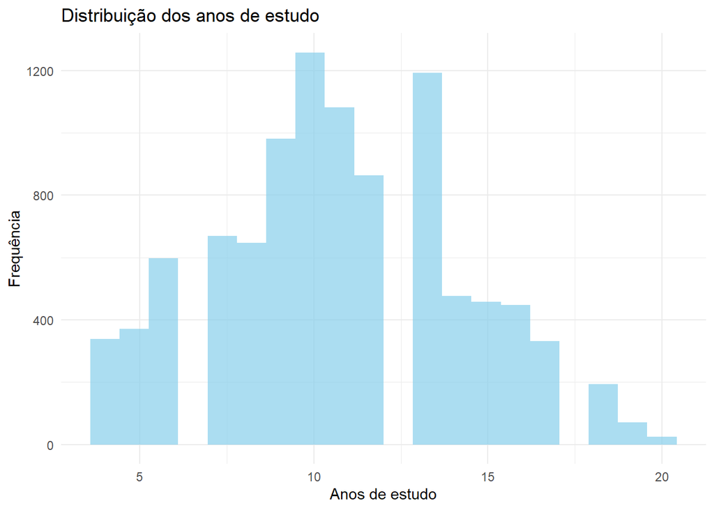

```r
# Histograma da variável de educação (anos de estudo)
ggplot(educ, aes(x = anos_estudo)) +
  geom_histogram(bins = 20, fill = "skyblue", alpha = 0.7) +
  labs(title = "Distribuição dos anos de estudo",
       x = "Anos de estudo", y = "Frequência") +
  theme_minimal()
```

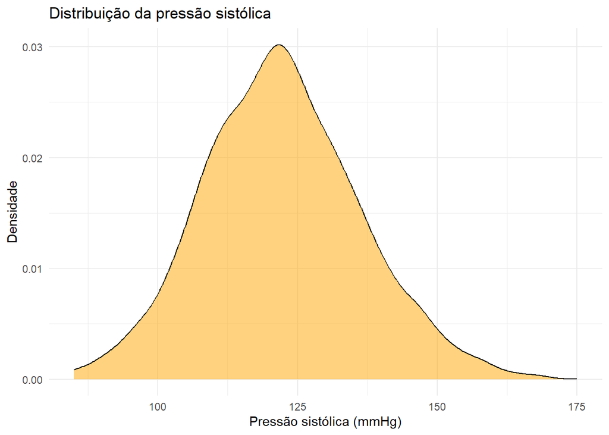

```r
# Densidade da variável de saúde (pressão sistólica)
ggplot(educ, aes(x = pressao_sistolica)) +
  geom_density(fill = "orange", alpha = 0.5) +
  labs(title = "Distribuição da pressão sistólica",
       x = "Pressão sistólica (mmHg)", y = "Densidade") +
  theme_minimal()
```

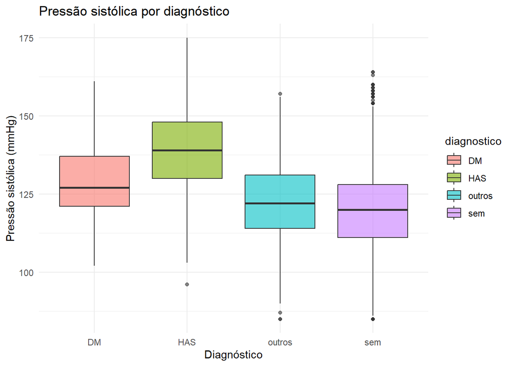

```r
# Boxplot da pressão sistólica por diagnóstico
ggplot(educ, aes(x = diagnostico, y = pressao_sistolica, fill = diagnostico)) +
  geom_boxplot(alpha = 0.6) +
  labs(title = "Pressão sistólica por diagnóstico",
       x = "Diagnóstico", y = "Pressão sistólica (mmHg)") +
  theme_minimal()
```